# Assessing variability and association of rice agronomic traits across subpopulations and regions

```r
#------------------------------------------------------------------------------

#sem for TEJ
data<-subset(norm1,subpopulation=='TEJ')
sitemod <- 'HHGW~FGN+PNN+FLN
            FGN~~PNN
            PNN~~FLN
            FGN~DTH+PTH
            PNN~DTH+PTH
            FLN~DTH+PTH
            DTH~~PTH'

# model/sem anylysis
sitemod.fit <- lavaan::sem(sitemod, data = data)

#summary of the results
summary(sitemod.fit, fit.measures=TRUE)
```

```
## lavaan 0.6-7 ended normally after 28 iterations
##
##   Estimator                                         ML
##   Optimization method                           NLMINB
##   Number of free parameters                         18
##
##   Number of observations                            92
##
## Model Test User Model:
##
##   Test statistic                               196.728
##   Degrees of freedom                                 3
##   P-value (Chi-square)                           0.000
##
## Model Test Baseline Model:
##
##   Test statistic                               334.740
##   Degrees of freedom                                15
##   P-value                                        0.000
##
## User Model versus Baseline Model:
##
##   Comparative Fit Index (CFI)                    0.394
##   Tucker-Lewis Index (TLI)                      -2.029
##
## Loglikelihood and Information Criteria:
##
##   Loglikelihood user model (H0)               -573.818
##   Loglikelihood unrestricted model (H1)       -475.454
##
##   Akaike (AIC)                                1183.636
##   Bayesian (BIC)                              1229.028
##   Sample-size adjusted Bayesian (BIC)         1172.210
##
## Root Mean Square Error of Approximation:
##
##   RMSEA                                          0.838
##   90 Percent confidence interval - lower         0.741
##   90 Percent confidence interval - upper         0.939
##   P-value RMSEA <= 0.05                          0.000
```

[output cut: 29 more lines]

```
##  .FGN ~~
##    .PNN               0.081    0.039    2.066    0.039
##  .PNN ~~
##    .FLN              -0.194    0.045   -4.336    0.000
##   DTH ~~
##     PTH               0.286    0.070    4.109    0.000
##
## Variances:
##                    Estimate  Std.Err  z-value  P(>|z|)
##    .HHGW              0.658    0.097    6.782    0.000
##    .FGN               0.518    0.076    6.782    0.000
##    .PNN               0.350    0.051    6.845    0.000
##    .FLN               0.436    0.064    6.782    0.000
##     DTH               0.780    0.115    6.782    0.000
##     PTH               0.468    0.069    6.782    0.000
```

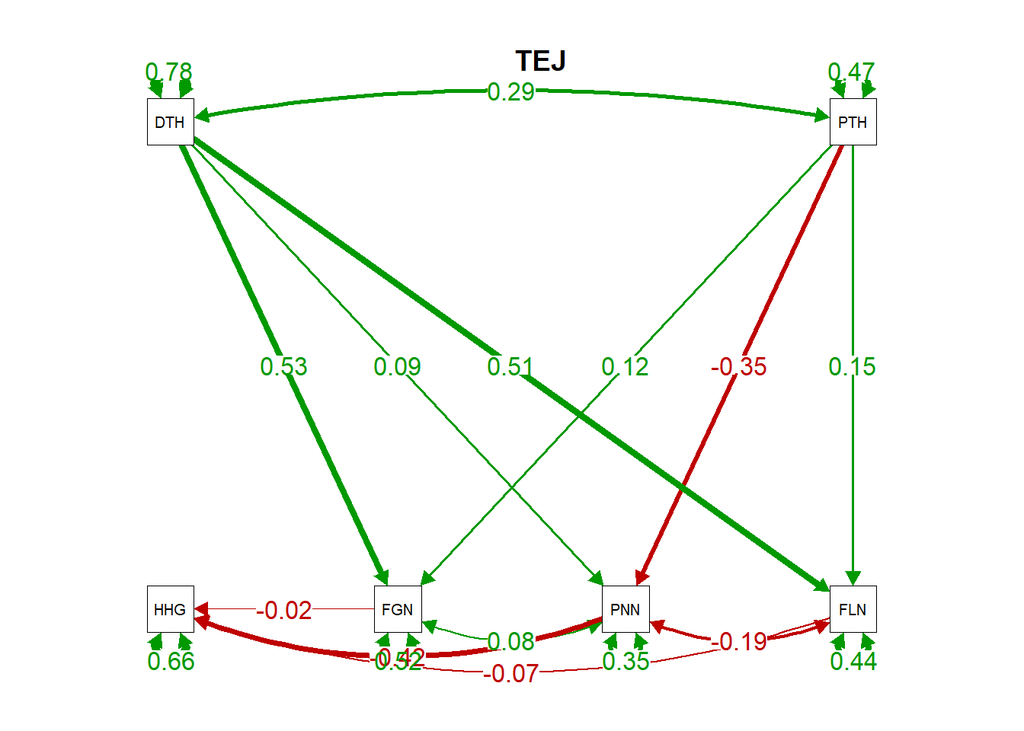

```r
#plot our CFA. you can change layout with layout = argument. see ?semPaths() for more.
semPlot::semPaths(sitemod.fit, "par", edge.label.cex = 1.2, fade = FALSE)
title("TEJ")
```

```r
#------------------------------------------------------------------------------

#sem for TRJ
data<-subset(norm1,subpopulation=='TRJ')
sitemod <- 'HHGW~FGN+PNN+FLN
            FGN~~PNN
            PNN~~FLN
            FGN~DTH+PTH
            PNN~DTH+PTH
            FLN~DTH+PTH
            DTH~~PTH'

# model/sem anylysis
sitemod.fit <- lavaan::sem(sitemod, data = data)

#summary of the results
summary(sitemod.fit, fit.measures=TRUE)
```

```
## lavaan 0.6-7 ended normally after 28 iterations
##
##   Estimator                                         ML
##   Optimization method                           NLMINB
##   Number of free parameters                         18
##
##   Number of observations                            85
##
## Model Test User Model:
##
##   Test statistic                               130.740
##   Degrees of freedom                                 3
##   P-value (Chi-square)                           0.000
##
## Model Test Baseline Model:
##
##   Test statistic                               226.559
##   Degrees of freedom                                15
##   P-value                                        0.000
##
## User Model versus Baseline Model:
##
##   Comparative Fit Index (CFI)                    0.396
##   Tucker-Lewis Index (TLI)                      -2.019
##
## Loglikelihood and Information Criteria:
##
##   Loglikelihood user model (H0)               -517.290
##   Loglikelihood unrestricted model (H1)       -451.920
##
##   Akaike (AIC)                                1070.580
##   Bayesian (BIC)                              1114.548
##   Sample-size adjusted Bayesian (BIC)         1057.762
##
## Root Mean Square Error of Approximation:
##
##   RMSEA                                          0.708
##   90 Percent confidence interval - lower         0.607
##   90 Percent confidence interval - upper         0.814
##   P-value RMSEA <= 0.05                          0.000
```

[output cut: 29 more lines]

```
##  .FGN ~~
##    .PNN              -0.049    0.033   -1.474    0.140
##  .PNN ~~
##    .FLN              -0.071    0.034   -2.069    0.039
##   DTH ~~
##     PTH               0.233    0.060    3.868    0.000
##
## Variances:
##                    Estimate  Std.Err  z-value  P(>|z|)
##    .HHGW              0.500    0.077    6.519    0.000
##    .FGN               0.864    0.133    6.519    0.000
##    .PNN               0.110    0.017    6.528    0.000
##    .FLN               0.890    0.136    6.519    0.000
##     DTH               0.363    0.056    6.519    0.000
##     PTH               0.698    0.107    6.519    0.000
```

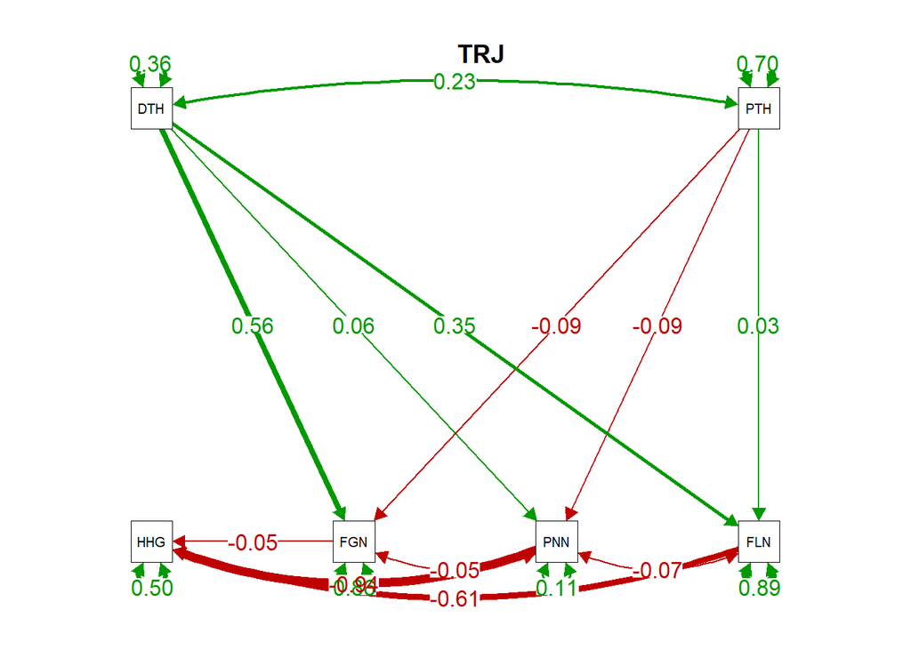

```r
#plot our CFA. you can change layout with layout = argument. see ?semPaths() for more.
semPlot::semPaths(sitemod.fit, "par", edge.label.cex = 1.2, fade = FALSE)
title("TRJ")
```

**Direct and Indirect Effects**

For all subpopulations, a negative direct effect on HHGW was observed in FLN. In ADMIX subpopulation, FGN, PNN and FLN accounted for 58% (R2 = 0.58) of the variation in HHGW. FLN had the strongest negative effect on HHGW (β = -0.77, p < 0.05), this implies that if FLN was increased by one standard deviation with FGN and PNN held constant, HHGW will decrease by 0.77 standard deviations. PNN negatively affected HHGW (β = -0.47), while FGN positively affected HHGW (β = 0.40) at p < 0.05. There was a significant indirect effect (p < 0.05) of PTH on HHGW via DTH and FLN. The double-headed arrow between DTH and PTH indicates a significant relationship (p < 0.05) but assumes no causality.

In ARO subpopulation, FLN, PNN and FGN accounted for 22 % (R2 = 0.22) of the variation in HHGW. The strongest negative direct effect was observed in FLN (β = -0.85, p < 0.05), while PNN and FGN had positive effects on HHGW. All indirect effects of PTH and DTH via FGN, PNN and FLN were all insignificant (p > 0.05). In AUS subpopulation, all agronomic traits accounted for 33% (R2 = 0.33) of the variation in HHGW. The strongest direct effect on HHGW was observed in FLN (β = -0.98, p < 0.05). PNN had a direct negative effect (β = -0.56, p < 0.05) while FGN had a direct positive effect (β = 0.46, p < 0.05). PTH and DTH had significant indirect effects on HHGW. PTH had effect on HHGW via FLN, PNN and FGN while DTH effect was via FGN and FLN.

For TRJ, FLN and PNN accounted for the total variation in HHGW (R2 = 0.50). Both traits had a negative direct effect on HHGW, (β = -0.61, p < 0.05) and (β = -0.94, p < 0.05) for FLN and PNN respectively. A significant indirect effect was observed in PTHT via DTH and FLN (p < 0.05), while other indirect effects were insignificant (p > 0.05).

**Path Summary**

```r
# Path summary
# I created a result summary table on excel
sem <- read.csv("./raw_data/SEM_result.csv")

sem %>%
  kbl(format = 'html') %>%
  kable_paper() %>%
  scroll_box(width = "700px",
             height = "350px")          # Using KableExtra table formatting
```

[output not shown]

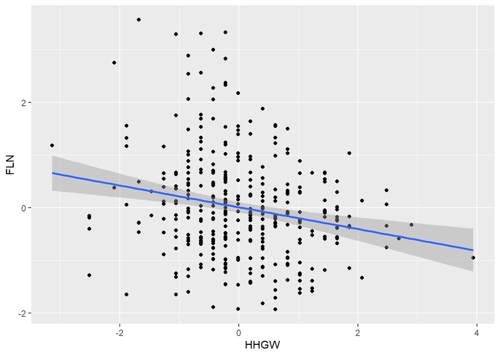

```r
# Does florescence per panicle predict test weight?

# Explore data
ggplot(norm1,
       aes(x = HHGW, y = FLN)) +
  geom_point() +
  stat_smooth(method = "lm")
```

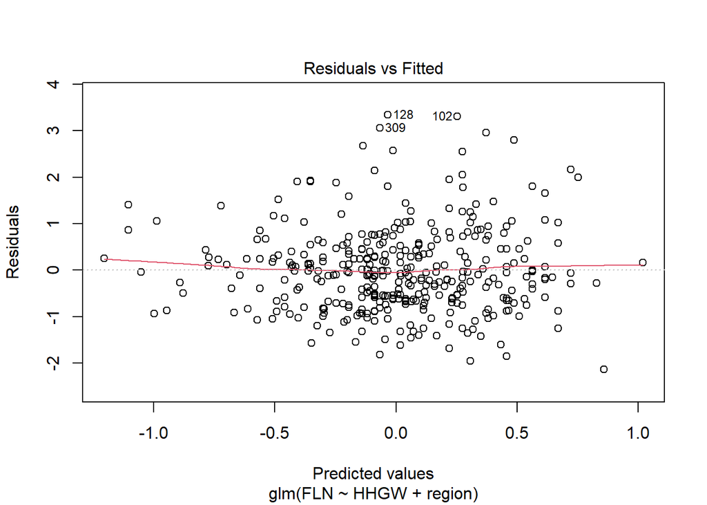

```r
# Fit a model
rice_mlr <- glm(FLN ~ HHGW + region,
                 data = norm1,
                 family = gaussian(link = "identity"))

# assumptions
plot(rice_mlr, which = 1)
```

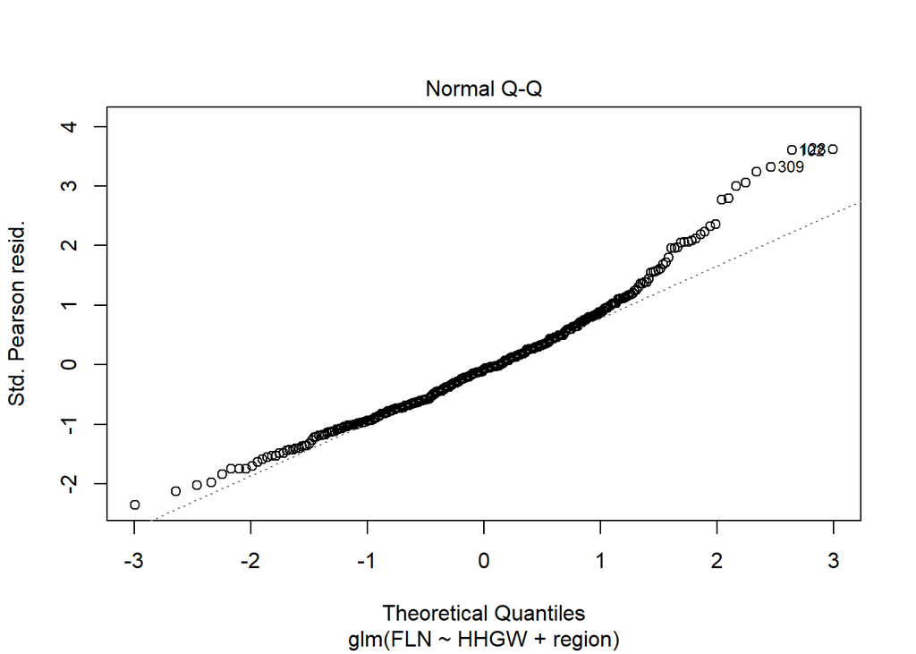

```r
plot(rice_mlr, which = 2)
```

```r
shapiro.test(residuals(rice_mlr))
```

```
##
##  Shapiro-Wilk normality test
##
## data:  residuals(rice_mlr)
## W = 0.96349, p-value = 6.921e-08
```

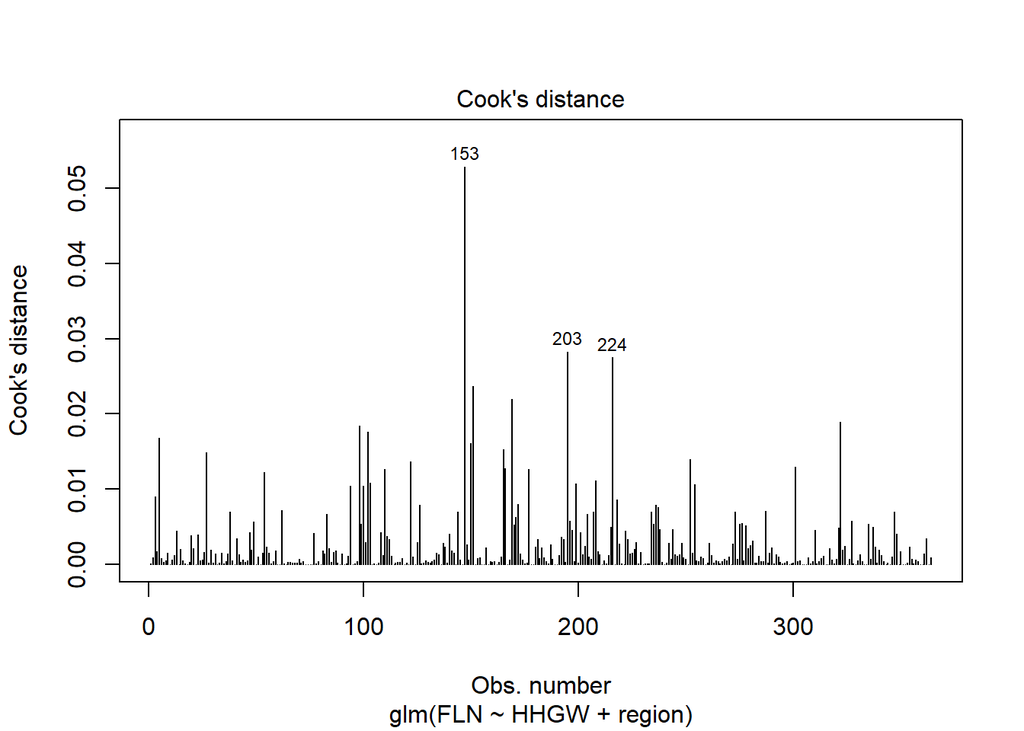

```r
plot(rice_mlr, which = 4)
```

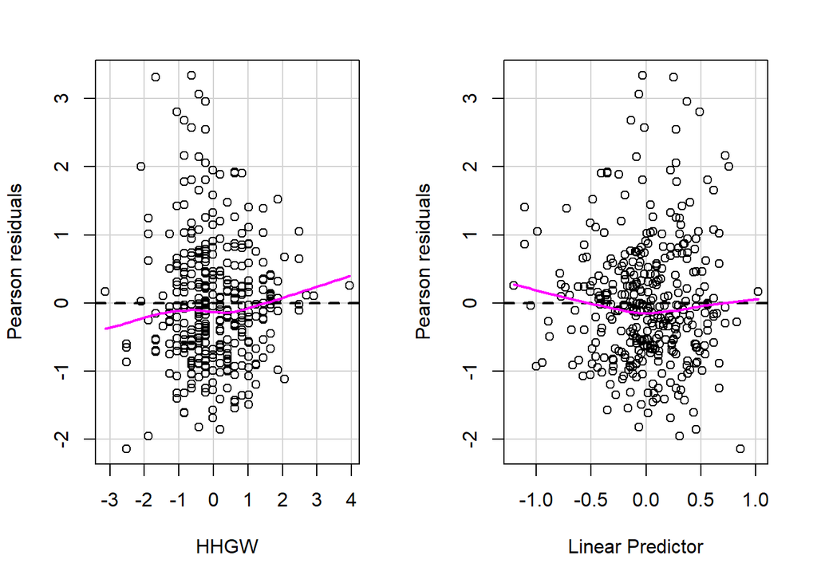

```
##      Test stat Pr(>|Test stat|)
## HHGW    0.0214           0.8838
```

```r
# view residuals
residualPlots(rice_mlr)
```

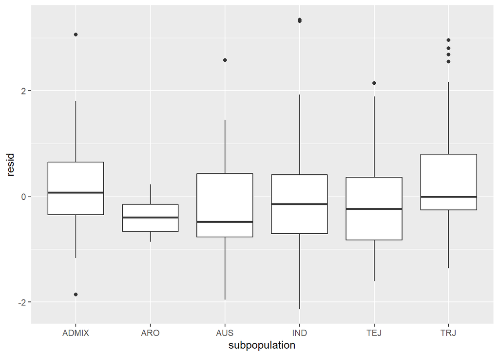

```r
# include residuals into data
norm1 <- norm1 %>%
  add_residuals(rice_mlr)

# plot residuals
qplot(subpopulation, resid, data = norm1, geom = "boxplot")
```

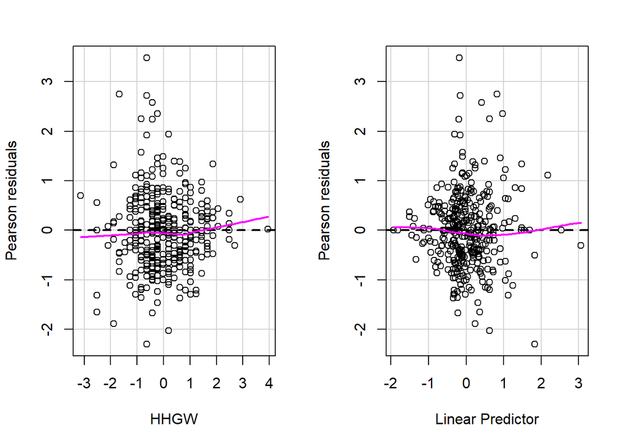

```
##      Test stat Pr(>|Test stat|)
## HHGW    0.0028            0.958
```

```r
# test of interaction between mass and species
rice_int <- glm(FLN ~ HHGW * region * subpopulation,
                 data = norm1,
                 family = gaussian(link = "identity"))

residualPlots(rice_int)
```

```r
Anova(rice_int)
```

```
## Analysis of Deviance Table (Type II tests)
##
## Response: FLN
##                           LR Chisq Df Pr(>Chisq)
## HHGW                        22.643  1  1.950e-06 ***
## region                      10.697 12    0.55507
## subpopulation               41.480  5  7.504e-08 ***
## HHGW:region                  8.996 12    0.70330
## HHGW:subpopulation           6.178  5    0.28931
## region:subpopulation        45.525 30    0.03447 *
## HHGW:region:subpopulation   16.529 19    0.62177
## ---
## Signif. codes:  0 '***' 0.001 '**' 0.01 '*' 0.05 '.' 0.1 ' ' 1
```

```r
Anova(rice_mlr)
```

```
## Analysis of Deviance Table (Type II tests)
##
## Response: FLN
##        LR Chisq Df Pr(>Chisq)
## HHGW     19.288  1  1.124e-05 ***
## region   40.182 12  6.708e-05 ***
## ---
## Signif. codes:  0 '***' 0.001 '**' 0.01 '*' 0.05 '.' 0.1 ' ' 1
```

```r
# post-hocs what is the effect of subpopulation and region at the average level of HHGW
rice_em <- emmeans(rice_mlr, specs = ~ region,
                    at = list(HHGW = 4))  # for specificity


# check which slopes are statistically different
rice_em %>%
  contrast(method = "tukey") %>%
  data.frame() %>%
  kbl(format = 'html') %>%
  kable_paper() %>%
  scroll_box(width = "700px",
             height = "350px")
```

| contrast | estimate | SE | df | z.ratio | p.value |
| --- | --- | --- | --- | --- | --- |
| Africa - Caribbean | 0.0337395 | 0.4092806 | Inf | 0.0824361 | 1.0000000 |
| Africa - Central America | -0.0732953 | 0.4088549 | Inf | -0.1792698 | 1.0000000 |
| Africa - Central Asia | 0.9839374 | 0.4125749 | Inf | 2.3848698 | 0.4546777 |
| Africa - East Asia | 0.5121375 | 0.1945159 | Inf | 2.6328831 | 0.2902848 |
| Africa - East Europe | 0.6681605 | 0.2842514 | Inf | 2.3505973 | 0.4795893 |
| Africa - North America | -0.1902123 | 0.2119240 | Inf | -0.8975497 | 0.9995857 |
| Africa - Oceania | 0.4180241 | 0.4131480 | Inf | 1.0118022 | 0.9986235 |
| Africa - South America | 0.2539267 | 0.2304817 | Inf | 1.1017221 | 0.9968816 |
| Africa - South Asia | 0.4909530 | 0.2105321 | Inf | 2.3319626 | 0.4932626 |
| Africa - Southeast Asia | 0.0977997 | 0.2125899 | Inf | 0.4600395 | 0.9999997 |
| Africa - West Asia | 1.1566380 | 0.3214016 | Inf | 3.5987313 | 0.0193922 |
| Africa - West Europe | 0.3249966 | 0.2551319 | Inf | 1.2738379 | 0.9884219 |
| Caribbean - Central America | -0.1070348 | 0.5362086 | Inf | -0.1996141 | 1.0000000 |
| Caribbean - Central Asia | 0.9501979 | 0.5372101 | Inf | 1.7687641 | 0.8653087 |
| Caribbean - East Asia | 0.4783980 | 0.3954042 | Inf | 1.2098963 | 0.9926346 |
| Caribbean - East Europe | 0.6344211 | 0.4489458 | Inf | 1.4131352 | 0.9725897 |
| Caribbean - North America | -0.2239518 | 0.4050367 | Inf | -0.5529173 | 0.9999978 |
| Caribbean - Oceania | 0.3842846 | 0.5374829 | Inf | 0.7149708 | 0.9999625 |
| Caribbean - South America | 0.2201873 | 0.4154044 | Inf | 0.5300552 | 0.9999987 |
| Caribbean - South Asia | 0.4572135 | 0.4017533 | Inf | 1.1380455 | 0.9957791 |
| Caribbean - Southeast Asia | 0.0640602 | 0.4044683 | Inf | 0.1583814 | 1.0000000 |
| Caribbean - West Asia | 1.1228985 | 0.4716060 | Inf | 2.3810096 | 0.4574661 |
| Caribbean - West Europe | 0.2912571 | 0.4326647 | Inf | 0.6731706 | 0.9999806 |
| Central America - Central Asia | 1.0572327 | 0.5379487 | Inf | 1.9653040 | 0.7557753 |
| Central America - East Asia | 0.5854329 | 0.3963321 | Inf | 1.4771271 | 0.9612775 |
| Central America - East Europe | 0.7414559 | 0.4486327 | Inf | 1.6527013 | 0.9130482 |
| Central America - North America | -0.1169170 | 0.4055887 | Inf | -0.2882649 | 1.0000000 |
| Central America - Oceania | 0.4913194 | 0.5382968 | Inf | 0.9127296 | 0.9995083 |
| Central America - South America | 0.3272221 | 0.4157816 | Inf | 0.7870046 | 0.9998949 |
| Central America - South Asia | 0.5642483 | 0.4034667 | Inf | 1.3985001 | 0.9747789 |
| Central America - Southeast Asia | 0.1710950 | 0.4054356 | Inf | 0.4220030 | 0.9999999 |
| Central America - West Asia | 1.2299333 | 0.4720944 | Inf | 2.6052697 | 0.3068046 |
| Central America - West Europe | 0.3982919 | 0.4316315 | Inf | 0.9227592 | 0.9994506 |
| Central Asia - East Asia | -0.4717999 | 0.3941696 | Inf | -1.1969464 | 0.9933115 |
| Central Asia - East Europe | -0.3157769 | 0.4516975 | Inf | -0.6990892 | 0.9999707 |
| Central Asia - North America | -1.1741497 | 0.4050387 | Inf | -2.8988582 | 0.1593394 |
| Central Asia - Oceania | -0.5659133 | 0.5361288 | Inf | -1.0555548 | 0.9979246 |
| Central Asia - South America | -0.7300107 | 0.4159540 | Inf | -1.7550275 | 0.8716449 |
| Central Asia - South Asia | -0.4929844 | 0.3977910 | Inf | -1.2393052 | 0.9908876 |
| Central Asia - Southeast Asia | -0.8861377 | 0.4030556 | Inf | -2.1985494 | 0.5922718 |
| Central Asia - West Asia | 0.1727006 | 0.4715593 | Inf | 0.3662330 | 1.0000000 |
| Central Asia - West Europe | -0.6589408 | 0.4379017 | Inf | -1.5047686 | 0.9554425 |
| East Asia - East Europe | 0.1560230 | 0.2677101 | Inf | 0.5828058 | 0.9999961 |
| East Asia - North America | -0.7023499 | 0.1786253 | Inf | -3.9319726 | 0.0056072 |
| East Asia - Oceania | -0.0941134 | 0.3942204 | Inf | -0.2387331 | 1.0000000 |
| East Asia - South America | -0.2582108 | 0.2020626 | Inf | -1.2778753 | 0.9881016 |
| East Asia - South Asia | -0.0211846 | 0.1623590 | Inf | -0.1304798 | 1.0000000 |
| East Asia - Southeast Asia | -0.4143378 | 0.1743633 | Inf | -2.3762901 | 0.4608816 |
| East Asia - West Asia | 0.6445004 | 0.3003711 | Inf | 2.1456808 | 0.6311814 |
| East Asia - West Europe | -0.1871409 | 0.2433461 | Inf | -0.7690318 | 0.9999179 |
| East Europe - North America | -0.8583729 | 0.2807830 | Inf | -3.0570690 | 0.1055434 |
| East Europe - Oceania | -0.2501364 | 0.4521913 | Inf | -0.5531651 | 0.9999978 |
| East Europe - South America | -0.4142338 | 0.2951159 | Inf | -1.4036310 | 0.9740272 |
| East Europe - South Asia | -0.1772076 | 0.2791821 | Inf | -0.6347383 | 0.9999899 |
| East Europe - Southeast Asia | -0.5703608 | 0.2810882 | Inf | -2.0291166 | 0.7136716 |
| East Europe - West Asia | 0.4884774 | 0.3704347 | Inf | 1.3186602 | 0.9844510 |
| East Europe - West Europe | -0.3431639 | 0.3153776 | Inf | -1.0881050 | 0.9972271 |
| North America - Oceania | 0.6082364 | 0.4052299 | Inf | 1.5009663 | 0.9562811 |
| North America - South America | 0.4441391 | 0.2209937 | Inf | 2.0097362 | 0.7267339 |
| North America - South Asia | 0.6811653 | 0.1894020 | Inf | 3.5963995 | 0.0195514 |
| North America - Southeast Asia | 0.2880121 | 0.1976721 | Inf | 1.4570191 | 0.9651515 |
| North America - West Asia | 1.3468503 | 0.3137507 | Inf | 4.2927399 | 0.0012543 |
| North America - West Europe | 0.5152090 | 0.2559775 | Inf | 2.0127116 | 0.7247432 |
| Oceania - South America | -0.1640974 | 0.4162045 | Inf | -0.3942709 | 1.0000000 |
| Oceania - South Asia | 0.0729289 | 0.3975169 | Inf | 0.1834611 | 1.0000000 |
| Oceania - Southeast Asia | -0.3202244 | 0.4030811 | Inf | -0.7944416 | 0.9998839 |
| Oceania - West Asia | 0.7386139 | 0.4717179 | Inf | 1.5657958 | 0.9403280 |
| Oceania - West Europe | -0.0930275 | 0.4386902 | Inf | -0.2120573 | 1.0000000 |
| South America - South Asia | 0.2370262 | 0.2126491 | Inf | 1.1146353 | 0.9965213 |
| South America - Southeast Asia | -0.1561270 | 0.2191544 | Inf | -0.7124065 | 0.9999640 |
| South America - West Asia | 0.9027112 | 0.3273863 | Inf | 2.7573277 | 0.2225328 |
| South America - West Europe | 0.0710699 | 0.2708806 | Inf | 0.2623661 | 1.0000000 |
| South Asia - Southeast Asia | -0.3931532 | 0.1824945 | Inf | -2.1543297 | 0.6248588 |
| South Asia - West Asia | 0.6656850 | 0.3068328 | Inf | 2.1695369 | 0.6136967 |
| South Asia - West Europe | -0.1659563 | 0.2596732 | Inf | -0.6390970 | 0.9999891 |
| Southeast Asia - West Asia | 1.0588382 | 0.3120686 | Inf | 3.3929662 | 0.0387769 |
| Southeast Asia - West Europe | 0.2271969 | 0.2582749 | Inf | 0.8796709 | 0.9996630 |
| West Asia - West Europe | -0.8316413 | 0.3520620 | Inf | -2.3622016 | 0.4711173 |

```
## Note: adjust = "tukey" was changed to "sidak"
## because "tukey" is only appropriate for one set of pairwise comparisons
```

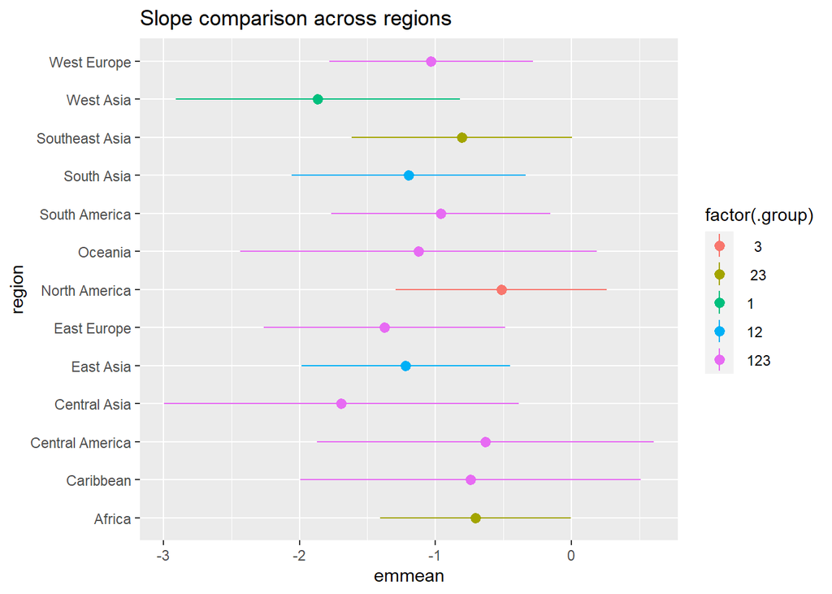

```r
# plot comparison
multcomp::cld(rice_em, adjust="tukey") %>%
  ggplot(aes(x = region, y = emmean,
             ymin = asymp.LCL, ymax = asymp.UCL,
             color = factor(.group))) +
  geom_pointrange() +
  coord_flip() +
  labs(title = "Slope comparison across regions")
```

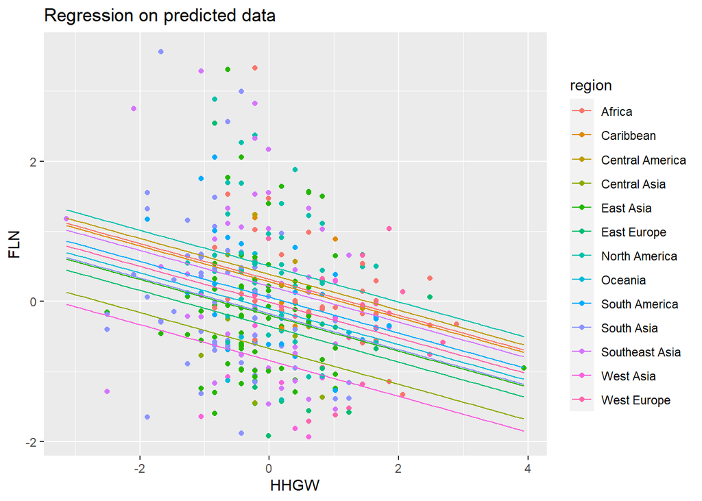

```r
# visualize!
rice_newdat <- modelr::data_grid(norm1,
                                  region = unique(region),
                                  HHGW = seq_range(HHGW, n = 100))


# create data predictions
rice_predict <- predict(rice_mlr,
                         newdata = rice_newdat,
                         type = "response",
                         interval = "confidence")

# add data predictions
rice_newdat <- rice_newdat %>%
  mutate(FLN = rice_predict)

# plot regression on predicted data
ggplot(norm1,
       aes(x = HHGW, y = FLN, color = region)) +
  geom_point()+
  geom_line(data = rice_newdat) +
  labs(title = "Regression on predicted data")
```

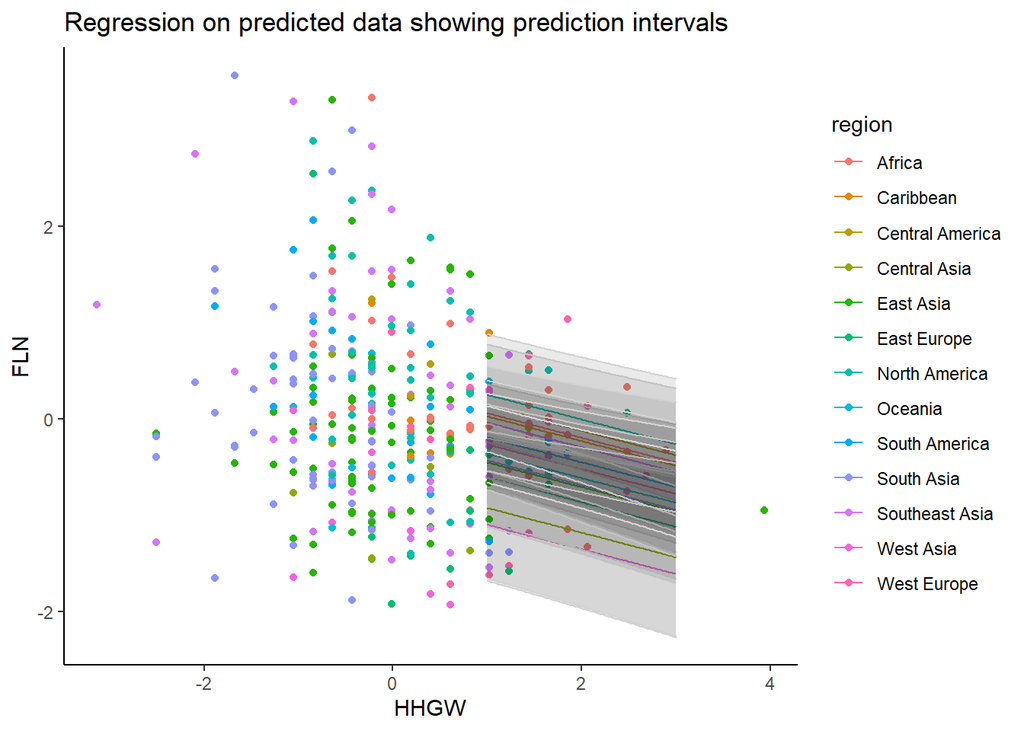

```r
# compare means of new fit
rice_newfit <- emmeans(rice_mlr, specs = ~ region + HHGW,
                        at = list(HHGW = seq(1,3, length.out = 100))) %>%
  as_tibble() %>%
  mutate(FLN = emmean)

# plot regresion slopes with prediction intervals
ggplot(norm1,
       aes(x = HHGW, y = FLN, color = region)) +
  geom_point() +
  geom_line(data = rice_newfit) +
  geom_ribbon(data = rice_newfit,
              aes(ymin = asymp.LCL, ymax = asymp.UCL, group = region, colour = region),
              alpha = 0.1, color = "lightgrey") +
  theme_classic() +
  labs(title = "Regression on predicted data showing prediction intervals")
```

# Discussion

Total florets per panicle has the most significant association with test weight which agrees with the result of (Ren et al., 2020), where altering meristem determinacy and restoring lateral floret formation significantly increased grains per panicle and subsequently yield. Plant height is a significant morphological trait influencing yield performance. Molecular cloning and functional analyses of several genes associated with PTH in rice have revealed connections to the synthesis and regulation of the phytohormone (gibberellin) (Miedaner et al., 2019). TEJ was observed to have the highest test weight which shows a significant relationship with plant height based on the SEM analysis. Indirect effect traits like DTH affects test weight via FLN and should be fully considered for breeding purposes in TEJ and TRJ subpopulations.

# Conclusion

# References

Deivasigamani S, & Swaminathan C. (2018). Evaluation of Seed Test Weight on Major Field Crops. Www.Arcjournals.Org International Journal of Research Studies in Agricultural Sciences, 4(1), 2454–6224. [crossref](https://doi.org/10.20431/2454-6224.0401001)

Eizenga, G. C., Ali, M. L., Bryant, R. J., Yeater, K. M., McClung, A. M., & McCouch, S. R. (2014). Registration of the Rice Diversity Panel 1 for Genomewide Association Studies. Journal of Plant Registrations, 8(1), 109–116. [crossref](https://doi.org/10.3198/jpr2013.03.0013crmp)

Li, R., Li, M., Ashraf, U., Liu, S., & Zhang, J. (2019). Exploring the relationships between yield and yield-related traits for rice varieties released in china from 1978 to 2017. Frontiers in Plant Science. [crossref](https://doi.org/10.3389/fpls.2019.00543)

Miedaner, T., Laidig, F., Zhao, J., Zhang, J., Li, R., Li, M., Ashraf, U., & Liu, S. (2019). Exploring the Relationships Between Yield and Yield-Related Traits for Rice Varieties Released in China From 1978 to 2017. [crossref](https://doi.org/10.3389/fpls.2019.00543)

Prakash Poudel, A. (2018). Analysis of Growth and Yield Attributing Characteristic of Direct Seeded Upland Rice Genotypes in Western Hills of Nepal. In Acta Scientific Agriculture (Vol. 2).

Puji Lestari, A., Sopandie, D., & Aswidinnoor, H. (2015). Panicle Length and Weight Performance of F3 Population from Local and Introduction Hybridization of Rice Varieties. HAYATI Journal of Biosciences April, 22(2), 87–92. [crossref](https://doi.org/10.4308/hjb.22.2.87)

Regression, M., & Models, E. (2005). c ontRibutions Commentary. Commentary, 86(October), 283–295. [crossref](http://www.esajournals.org/doi/abs/10.1890/0012-9623(2007)88[72:AHOTES]2.0.CO;2

Ren, D., Li, Y., He, G., & Qian, Q. (2020). Multifloret spikelet improves rice yield. New Phytologist, 225(6), 2301–2306.[crossref] (https://doi.org/10.1111/nph.16303)

Saleh, M. M., Salem, K. F. M., & Elabd, A. B. (2020). Definition of selection criterion using correlation and path coefficient analysis in rice (Oryza sativa L .) genotypes.

Venkateswarlu, B., Prasad, G. S. V, & Prasad, A. S. R. (n.d.). STUDIES ON THE NATURE OF RELATIONSHIPS BETWEEN GRAIN SIZE , SPIKELET NUMBER , GRAIN YIELD AND SPIKELET FILLING IN LATE DURATION VARIETIES OF RICE ( OR YZA SA TIVA L .) Grain number Grain size Productivity Rate of grain growth Rice Spikelet filling. 130(1981), 123–130.